# Analysis Report: Dog Rate Project

For my analysis, I wanted to focus on the dog_stages and how people react in the twitter environment by this I’m referring the likes and retweets that the tweets got according to the dog_stages.

In this first plot we can see that pupper is the most tweeted dog_stage in this dataset with more than 200 tweets, followed by doggo, puppo and in the last place is floofer. According to the definition of the Dogtionary, a pupper is a small dog, usually younger.

Fig 1. Dog Stages

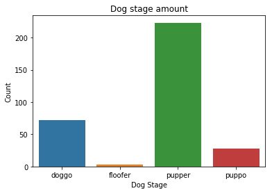

Ok, now that I know that pupper is the most tweeted dog stage I wanna know how the favorite_count from each tweet interact with the dog stages.

In the fig. 2 we can see that the number of favorites is gathered around the values of 0 - 25000, with some outliers around 125000 - 150000

Fig 2. Favorites vs Dog Stage

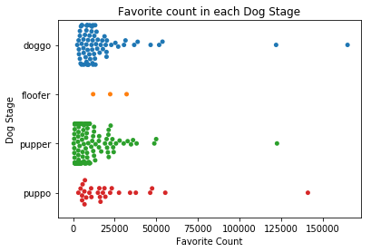

Now, I want to know the interaction between retweets_count from each tweet and the dog stages.

And we can see in the fig. 3 that the number of retweets is gather around the values of 0 - 20000, with some outliers around 40000 - 80000.

Fig 3. Retweets vs Dog Stage

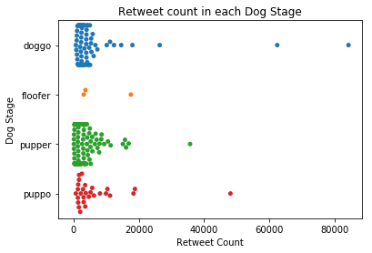

I created the rating ratio column that is the fraction between rating_numerator and rating_denominator, so in the next plot, we can see that the most frequent values are 1.2, 1 and 1.1.

Fig 4. Rating Ratio plot

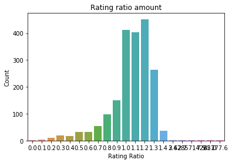

Fig 5. Rating Ratio vs Dog Stage

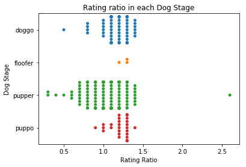

From the dataset, I got that the most tweeted dog breed is the Golden Retriever so I wanna know which dog stage is the most tweeted and as we can see in the graphic 6, the pupper is the one with most tweets, followed by doggo, puppo, and floofer in the last place.

Fig 6. Golden Retriever plot

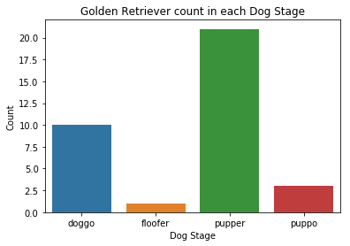